# Predicting heart disease diagnosis

## Introduction

Heart disease encompasses all conditions that affect the normal functioning of the heart. This includes conditions that affect the cardiac muscle, such as arrhythmia, to the narrowing of blood vessels that can lead to heart attacks and strokes. According to the World Health Organization (2017), heart disease is one of the global leading causes of mortality, contributing to 17.9 million deaths per year. Unfortunately, cardiac disease can be difficult to diagnose as there are many potential contribution factors. We aim to design a classification model that will be able to predict diagnosis of heart disease and to analyze the accuracy of this model. The proposed prediction model would allow physicians to efficiently evaluate the presence of heart disease in patients. With this information, physicians can propose lifestyle changes and provide treatments to prevent worsening of heart condition.

The model will be designed based on the Heart Disease dataset from the UCI Machine Learning Repository (https://archive.ics.uci.edu/ml/datasets/Heart+Disease). A total of 920 observations were collected from four locations: Cleveland (USA), Budapest (Hungary), Long Beach (USA), and Zurich (Switzerland). This dataset contains the diagnosis of heart disease and 14 attributes relating to heart disease.

Among these attributes, we will use age, old peak, cholesterol levels, fasting blood sugar levels, resting blood pressure, and maximum heart rate achieved as explanatory variables for the classification model. These 6 attributes were selected because they have previously been demonstrated to have physiological relevance to heart disease in literature. Age is a significant contributor to onset heart disease as the natural aging process leads to the deterioration of heart and blood vessel condition (Oxenham & Sharpe, 2003). Old peak describes exercise-induced depression of the ST segment in an electrocardiogram. This segment represents the voltage activity of the heart between ventricular depolarization and ventricular repolarization. ST depression can be indicative of cardiac problems like three-vessel disease and left main stenosis (Diderholm et al., 2002). Cholesterol is a type of lipid that travels through the cardiovascular system. High cholesterol content in the bloodstream can lead to plaque formation and subsequently, the narrowing or blocking of arteries (Kratz, 2005). Similarly, high blood pressure and maximum heart rate can accelerate the development of plaques in addition to causing damage to blood vessels (Lawes et al., 2002). High fasting blood sugar is an indication of glucose intolerance that has been associated with the incidence of heart diseases like left ventricular hypertrophy and diastolic dysfunction (Nielson & Lange, 2005). Using this model based on the Heart Disease dataset, we aim to answer the question “Will a person be diagnosed with heart disease?”

## Preliminary Exploratory Data Analysis

```r
library(tidyverse)
library(tidymodels)
library(GGally)
set.seed(1)
```

[output not shown]

Here is how we load our data from the following web source.

```r
base_url = "https://archive.ics.uci.edu/ml/machine-learning-databases/heart-disease/"
cleveland_url = "processed.cleveland.data"
hungarian_url = "processed.hungarian.data"
switzerland_url = "processed.switzerland.data"
va_url = "processed.va.data"

if (!file.exists("data")) {
    dir.create("data")
}

download_dataset = function(path) {
    download.file(url = paste(base_url, path, sep = ""), destfile = paste("data/", path, sep = ""))
}

download_dataset(cleveland_url)
download_dataset(hungarian_url)
download_dataset(switzerland_url)
download_dataset(va_url)
```

The appropriate column names are created for our dataframe.

```r
col_names = c("age","sex", "chest_pain_type", "resting_blood_pressure", "cholesterol",
              "fasting_blood_sugar", "resting_ecg", "maximum_heart_rate_achieved", "exercise_induced_angina",
              "old_peak", "slope", "num_major_vessels", "thal", "diagnosis")
```

Here we create a function called load_dataset that can be used to read the csv file from the given file path and then wrangle each dataset necessary for our analysis.

```r
load_dataset = function(name) {
    dataframe = read_csv(file = paste("data/", name, sep = ""), col_names = col_names) %>% drop_na()

    diagnosis_0 = dataframe %>% filter(diagnosis == 0)

    dataframe = dataframe %>%
        filter(diagnosis != 0) %>%
        mutate(diagnosis = 1) %>%
        rbind(diagnosis_0) %>%
        mutate(diagnosis = factor(diagnosis, labels = c("No heart disease", "Heart disease")),
               sex = factor(sex, labels = c("Female", "Male")),
               thal = as_factor(thal),
               num_major_vessels = as.numeric(num_major_vessels),
               slope = as_factor(slope),
               exercise_induced_angina = as_factor(exercise_induced_angina),
               resting_ecg = as_factor(resting_ecg),
               fasting_blood_sugar = as_factor(fasting_blood_sugar),
               chest_pain_type = factor(chest_pain_type, labels = c("Typical angina", "Atypical angina", "Non-anginal pain", "Asymptomatic")),
               maximum_heart_rate_achieved = as.numeric(maximum_heart_rate_achieved),
               resting_blood_pressure = as.numeric(resting_blood_pressure),
               old_peak = as.numeric(old_peak),
               cholesterol = as.numeric(cholesterol))

    # Filter out NAs
    dataframe = dataframe %>%
        select(diagnosis, old_peak, age, cholesterol, maximum_heart_rate_achieved,
               fasting_blood_sugar, resting_blood_pressure) %>%
        filter(!is.na(old_peak), !is.na(age), !is.na(cholesterol),
               !is.na(maximum_heart_rate_achieved), !is.na(fasting_blood_sugar),
               !is.na(resting_blood_pressure))

    dataframe
}
```

Applying the load_dataset function to each dataset.

```r
cleveland = load_dataset(cleveland_url)
hungary = load_dataset(hungarian_url)
switzerland = load_dataset(switzerland_url)
va = load_dataset(va_url)
```

[output not shown]

[output cut: 32 more lines]

[output not shown]

Here we combine all of our loaded datasets into one large data frame named `health`.

```r
health = rbind(cleveland, switzerland) %>%
    rbind(va) %>%
    rbind(hungary)

nrow(health)
```

827

We split our data into a training and testing set. We use 70% of the data for training and 30% of the data for testing. Our target variable is `diagnosis` of heart disease.

```r
health_split = initial_split(data = health, prop = 0.7, strata = diagnosis)
health_training = training(health_split)
health_testing = testing(health_split)
head(health_training)
```

A tibble: 6 × 7

| diagnosis <fct> | old_peak <dbl> | age <dbl> | cholesterol <dbl> | maximum_heart_rate_achieved <dbl> | fasting_blood_sugar <fct> | resting_blood_pressure <dbl> |
| --- | --- | --- | --- | --- | --- | --- |
| Heart disease | 2.6 | 67 | 229 | 129 | 0 | 120 |
| Heart disease | 3.6 | 62 | 268 | 160 | 0 | 140 |
| Heart disease | 1.4 | 63 | 254 | 147 | 0 | 130 |
| Heart disease | 3.1 | 53 | 203 | 155 | 1 | 140 |
| Heart disease | 0.6 | 56 | 256 | 142 | 1 | 130 |
| Heart disease | 1.0 | 48 | 229 | 168 | 0 | 110 |

Table 1. Sample Training Data from the Heart Disease Dataset

We summarized the data in a table showing the number of observations of each diagnosis as well as the averages of the attributes that we plan to use for prediction. We will explore the training set further by plotting histograms that compare the distribution for each of the predictor variables.

```r
data_summary = health_training %>%
    group_by(diagnosis) %>%
    summarize(n = n(), avg_old_peak = mean(old_peak, na.rm = TRUE),
              avg_age = mean(age),
              avg_cholesterol = mean(cholesterol, na.rm = TRUE),
              avg_max_heartrate = mean(maximum_heart_rate_achieved, na.rm = TRUE),
              avg_bp = mean(resting_blood_pressure))


data_summary
```

A tibble: 2 × 7

| diagnosis <fct> | n <int> | avg_old_peak <dbl> | avg_age <dbl> | avg_cholesterol <dbl> | avg_max_heartrate <dbl> | avg_bp <dbl> |
| --- | --- | --- | --- | --- | --- | --- |
| No heart disease | 260 | 0.4238462 | 50.20000 | 223.2346 | 149.1538 | 129.2423 |
| Heart disease | 320 | 1.1981250 | 55.79375 | 173.3469 | 128.1094 | 133.4906 |

Table 2. Summary of Average Predictor Values for each Diagnosis

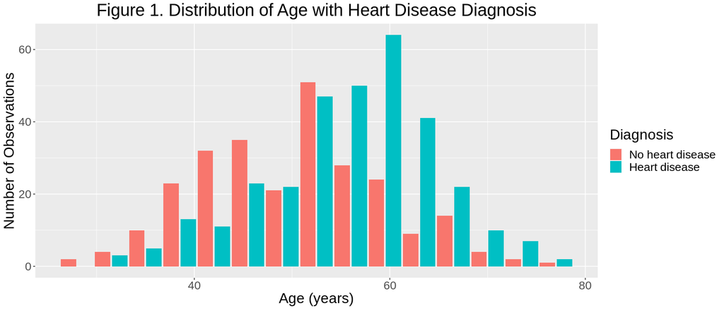

```r
options(repr.plot.width = 14, repr.plot.height = 6)
age_histogram = ggplot(health_training, aes(x = age, fill = diagnosis)) +
    geom_histogram(position = position_dodge2(), bins = 15) +
    labs(x = "Age (years)", y = "Number of Observations", fill = "Diagnosis") +
    theme(text = element_text(size = 20),
         plot.title = element_text(hjust = 0.5)) +
    ggtitle("Figure 1. Distribution of Age with Heart Disease Diagnosis")
age_histogram
```

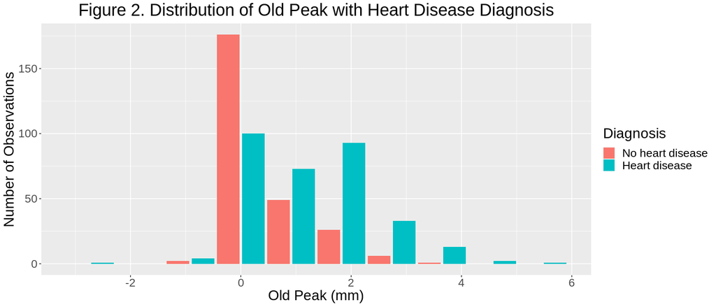

```r
old_peak_histogram = ggplot(health_training, aes(x = old_peak, fill = diagnosis)) +
    geom_histogram(position = position_dodge2(preserve = "single"), bins = 10) +
    labs(x = "Old Peak (mm)", y = "Number of Observations", fill = "Diagnosis") +
    theme(text = element_text(size = 20),
         plot.title = element_text(hjust = 0.5)) +
    ggtitle("Figure 2. Distribution of Old Peak with Heart Disease Diagnosis")
old_peak_histogram
```

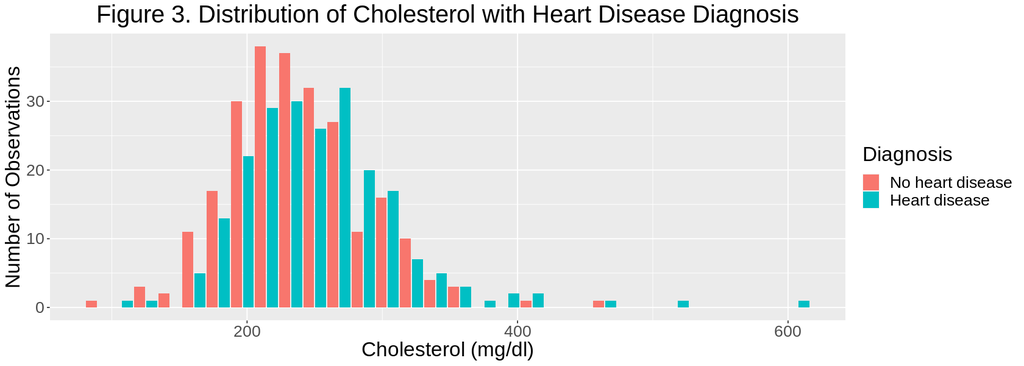

```r
options(repr.plot.width = 14, repr.plot.height = 5)

cholesterol = health_training %>% filter(cholesterol != 0)
cholesterol_histogram = ggplot(cholesterol, aes(x = cholesterol, fill = diagnosis)) +
    geom_histogram(position = position_dodge2(), bins = 30) +
    labs(x = "Cholesterol (mg/dl)", y = "Number of Observations", fill = "Diagnosis") +
    theme(text = element_text(size = 20),
         plot.title = element_text(hjust = 0.5)) +
    ggtitle("Figure 3. Distribution of Cholesterol with Heart Disease Diagnosis")
cholesterol_histogram
```

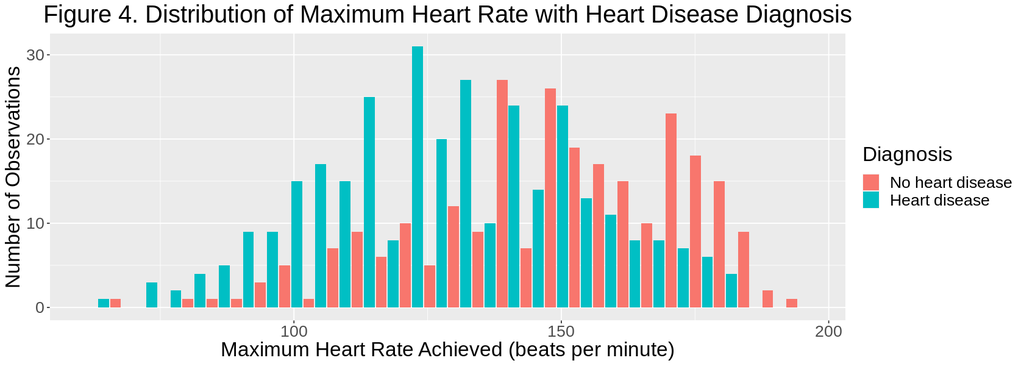

```r
heartrate_histogram = ggplot(health_training, aes(x = maximum_heart_rate_achieved, fill = diagnosis)) +
    geom_histogram(position = position_dodge2(preserve = "single"), bins = 30) +
    labs(x = "Maximum Heart Rate Achieved (beats per minute)", y = "Number of Observations", fill = "Diagnosis") +
    theme(text = element_text(size = 20),
         plot.title = element_text(hjust = 0.5)) +
    ggtitle("Figure 4. Distribution of Maximum Heart Rate with Heart Disease Diagnosis")
heartrate_histogram
```

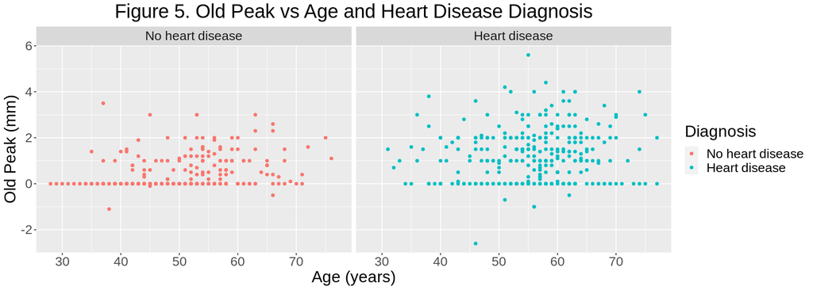

```r
options(repr.plot.width = 14, repr.plot.height = 5)

training_plot = ggplot(health_training, aes(x = age, y = old_peak, colour = diagnosis)) +
    geom_point(alpha = 1) +
    labs(x = "Age (years)", y = "Old Peak (mm)", colour = "Diagnosis") +
    theme(text = element_text(size = 20),
         plot.title = element_text(hjust = 0.5)) +
    facet_grid(. ~ diagnosis) +
    ggtitle("Figure 5. Old Peak vs Age and Heart Disease Diagnosis")

training_plot
```

## Methods

The dataset was generally already tidy. We concatenated the individual datasets into one larger dataframe and converted numeric-based values in the data set to character values that better describe the attributes.

In order to analyze the dataset, we used classification by K-nearest neighbours to build a classifier model that would allow us to predict a heart disease diagnosis. The attributes used to build the model were age, old peak, cholesterol levels, fasting blood sugar levels, resting blood pressure, and maximum heart rate achieved. For clarification, old peak represents the ST depression induced by exercise relative to rest when looking at an electrocardiogram. We chose these attributes because of their relevance in literature. Furthermore, these attributes display a difference in frequency distribution between the absence and presence of heart disease. Thus, these attributes may be useful in classifying new data with a diagnosis.

In order to choose the best K value for our classifier model, we used cross validation on the training data set. The classifier model was then used to predict heart disease diagnosis on the testing dataset. The accuracy of our classifier object was then evaluated. A confusion matrix was generated for the classifier, which revealed the number of observations that were labelled correctly and incorrectly.

## Results

We constructed and prepared the recipe using the training data to ensure that all numeric variables are scaled and centered. Rows in the dataframe with missing values were removed. We then created a model specification for our K-nearest neighbour classification model. A 5-fold cross-validation technique was done on the training set.

```r
health_recipe <- recipe(diagnosis ~ old_peak + age + cholesterol + maximum_heart_rate_achieved +
                        fasting_blood_sugar + resting_blood_pressure, data = health_training) %>%
                step_scale(all_numeric()) %>%
                step_center(all_numeric()) %>%
                step_naomit(all_predictors())
health_recipe
knn_spec <- nearest_neighbor(weight_func = "rectangular", neighbors = tune()) %>%
            set_engine("kknn") %>%
            set_mode("classification")
knn_spec
health_vfold <- vfold_cv(data = health_training, v = 5, strata = diagnosis)
```

```
Data Recipe

Inputs:

      role #variables
   outcome          1
 predictor          6

Operations:

Scaling for all_numeric()
Centering for all_numeric()
Removing rows with NA values in all_predictors()
```

```
K-Nearest Neighbor Model Specification (classification)

Main Arguments:
  neighbors = tune()
  weight_func = rectangular

Computational engine: kknn
```

```r
health_results <- workflow() %>%
                    add_recipe(health_recipe) %>%
                    add_model(knn_spec) %>%
                    tune_grid(resamples = health_vfold, grid = 10) %>%
                    collect_metrics()
health_results
```

A tibble: 18 × 7

| neighbors <int> | .metric <chr> | .estimator <chr> | mean <dbl> | n <int> | std_err <dbl> | .config <chr> |
| --- | --- | --- | --- | --- | --- | --- |
| 2 | accuracy | binary | 0.6431034 | 5 | 0.01206897 | Model1 |
| 2 | roc_auc | binary | 0.7205228 | 5 | 0.01734261 | Model1 |
| 3 | accuracy | binary | 0.7017241 | 5 | 0.01237302 | Model2 |
| 3 | roc_auc | binary | 0.7362079 | 5 | 0.01973546 | Model2 |
| 4 | accuracy | binary | 0.7017241 | 5 | 0.01237302 | Model3 |
| 4 | roc_auc | binary | 0.7621695 | 5 | 0.02328333 | Model3 |
| 6 | accuracy | binary | 0.7275862 | 5 | 0.02191080 | Model4 |
| 6 | roc_auc | binary | 0.7863582 | 5 | 0.02971385 | Model4 |
| 7 | accuracy | binary | 0.7448276 | 5 | 0.02866946 | Model5 |
| 7 | roc_auc | binary | 0.7897536 | 5 | 0.02864598 | Model5 |
| 9 | accuracy | binary | 0.7465517 | 5 | 0.02892752 | Model6 |
| 9 | roc_auc | binary | 0.7975060 | 5 | 0.02786493 | Model6 |
| 10 | accuracy | binary | 0.7465517 | 5 | 0.02892752 | Model7 |
| 10 | roc_auc | binary | 0.7974760 | 5 | 0.03067352 | Model7 |
| 12 | accuracy | binary | 0.7482759 | 5 | 0.03003664 | Model8 |
| 12 | roc_auc | binary | 0.8090745 | 5 | 0.03024986 | Model8 |
| 15 | accuracy | binary | 0.7620690 | 5 | 0.02679357 | Model9 |
| 15 | roc_auc | binary | 0.8112981 | 5 | 0.03016459 | Model9 |

Table 3. Summary of Cross Validation Accuracy for Various Numbers of Neighbors

In order to select the best value of K, the number of neighbors was plotted against their respective accuracy estimates.

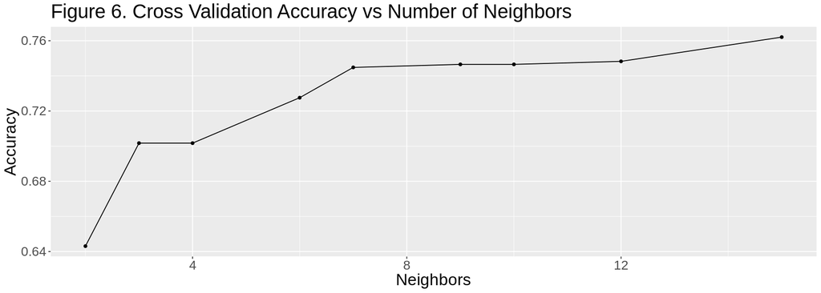

```r
health_accuracies = health_results %>%
    filter(.metric == "accuracy")

health_cv_plot = ggplot(health_accuracies, aes(x = neighbors, y = mean)) +
    geom_point() +
    geom_line() +
    labs(x = "Neighbors", y = "Accuracy") +
    theme(text = element_text(size = 20)) +
    ggtitle("Figure 6. Cross Validation Accuracy vs Number of Neighbors")

health_cv_plot
```

The final classifier model is then built using the best K value obtained. The best K was found to be K = 15.

```r
best_k = health_accuracies %>%
    arrange(desc(mean)) %>%
    head(1) %>%
    select(neighbors) %>%
    pull()

best_k

best_health_spec = nearest_neighbor(weight_func = "rectangular", neighbors = best_k) %>%
    set_engine("kknn") %>%
    set_mode("classification")

health_fit = workflow() %>%
    add_model(best_health_spec) %>%
    add_recipe(health_recipe) %>%
    fit(data = health_training)
```

15

In order to visualize how well each attribute predicts the diagnosis, we construct a ggpairs plot that will allow us to view density distribution plots for each attributes.

```r
training_results = health_fit %>%
    predict(new_data = health_training) %>%
    bind_cols(health_training)
```

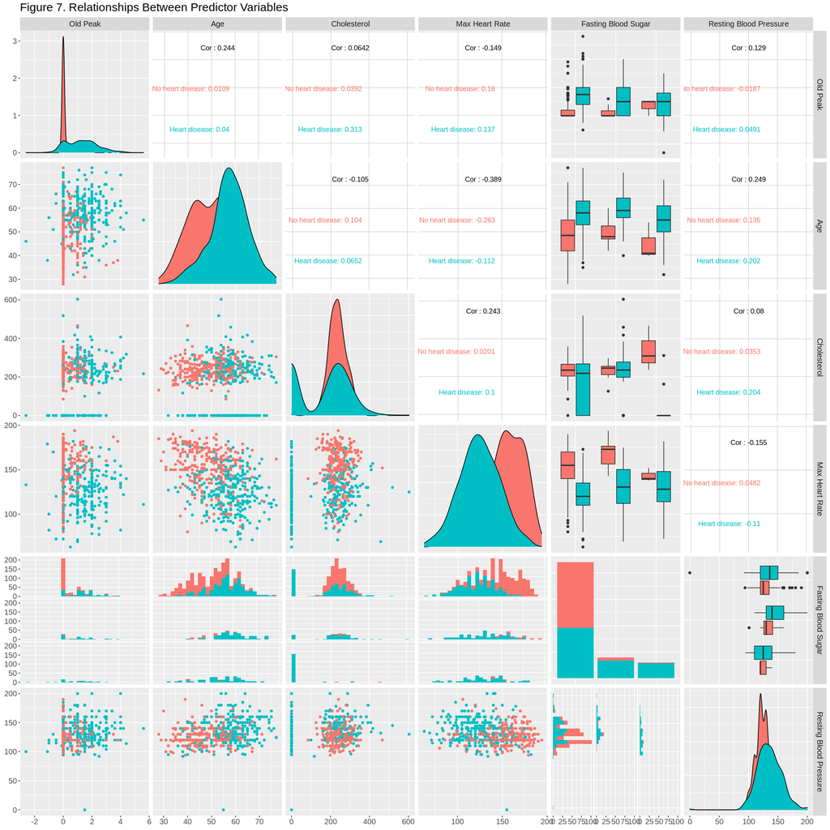

```r
options(repr.plot.width = 18, repr.plot.height = 18)

col_labels = c("Old Peak", "Age", "Cholesterol", "Max Heart Rate",
               "Fasting Blood Sugar", "Resting Blood Pressure")

training_plot = ggpairs(data = training_results, columns = 3:ncol(training_results), columnLabels = col_labels,
                        ggplot2::aes(colour = .pred_class)) +
                    theme(text = element_text(size=15)) +
                    ggtitle("Figure 7. Relationships Between Predictor Variables")

training_plot
```

The final classifier model is used to predict on the testing set and visualize the accuracy using a confusion matrix

```r
testing_predictions = health_fit %>%
    predict(new_data = health_testing) %>%
    bind_cols(health_testing)

testing_conf_mat = conf_mat(data = testing_predictions, truth = diagnosis, estimate = .pred_class)
testing_conf_mat

testing_accuracy = testing_predictions %>%
    metrics(truth = diagnosis, estimate = .pred_class) %>%
    filter(.metric == "accuracy")

testing_accuracy
```

```
                  Truth
Prediction         No heart disease Heart disease
  No heart disease               82            31
  Heart disease                  29           105
```

A tibble: 1 × 3

| .metric <chr> | .estimator <chr> | .estimate <dbl> |
| --- | --- | --- |
| accuracy | binary | 0.757085 |

Table 4. Prediction Accuracy of KNN Model on Testing Data

## Discussion

In order to investigate if a person will be diagnosed with heart disease, a classification using K-nearest neighbors was conducted on a Heart Disease dataset from the UCI Machine Learning Repository. The following predictors were used to design the classifier model - age, cholesterol levels, fasting blood sugar levels, resting blood pressure, maximum heart rate and old peak.

In order to choose the best K for our classifier, we used cross-validation. The results of cross-validation on our training set revealed that a value of K=15 generates the highest estimates of prediction accuracy at approximately 76%. Furthermore, nearby values of K such as K=12 did not decrease our prediction accuracy by a large amount. However, we found that smaller values of K decreased the prediction accuracy estimate. For example, K=4 resulted in a prediction accuracy of 70%. As a result, our choice for K=15 is the most reliable when building the final classifier model based on the best K.

Our final K-nearest neighbor classifier model was used to predict the class labels in our testing set. The final model has an accuracy of 75% on our testing data. This result suggests that we are neither under fitting or overfitting the data since the test accuracy is close to the training accuracy.

However, there are limitations to our model as it only predicts heart disease on our testing set with 75% accuracy. Our model only analyzed 6 predictors out of a variety of predictors that may be linked to heart disease. It is possible that there are other predictors that have a larger influence on whether an individual has heart disease compared to the predictors we chose. For example, obesity is another major risk factor that has been linked to the development of heart disease (Rodgers et al., 2019). This is a predictor that was not available in our dataset. For future analysis, it would be worthwhile to investigate whether BMI can be used as a predictor for heart disease. Our dataset also did not include predictors related to the lifestyle of an individual. Smoking and physical inactivity are other factors that contribute to heart disease (Khan et al., 2015). Obtaining information regarding these variables can be useful in potentially strengthening our model.

Given the 75% accuracy of our classifier model, it is not ideal for making accurate diagnoses in a medical context. The model should be improved by including a different set of predictors. Predictors that have been previously shown to predict heart disease in clinical trials should be included. However, our model can potentially be used in preliminary testing to supplement other medical testing to diagnose heart disease. In the future, it would be valuable to investigate whether predictive variables influence each other in any way. In other words, does one predictive variable have an influence on another predictive variable? Such research would be worthwhile as many individuals who have heart disease tend to be comorbid with conditions such as obesity, diabetes or hypertension. Therefore, investigating predictors such as BMI, blood sugar and blood pressure levels could allow us to determine relationships among variables and their influence on heart disease risk and prevalence.

## References

Diderholm, E., Andren, B., Frostfeldt, G., & The Fast Revascularization during InStability in Coronary artery disease (FRISC II) Investigators (2002). ST depression in ECG at entry indicates severe coronary lesions and large benefits of an early invasive treatment strategy in unstable coronary artery disease. *ACC Current Journal Review*, 11(3), 12-12.

Hajar, R. (2017). Risk factors for coronary artery disease: Historical perspectives. *Heart Views*, 18(3), 109-114.

Khan, R. J., Stewart, C. P., Davis, S. K., Harvey, D. J., & Leistikow, B. N. (2015). The risk and burden of smoking related heart disease mortality among young people in the united states. *Tobacco Induced Diseases*, 13(1), 16-16.

Kratz, M. (2005). Dietary cholesterol, atherosclerosis and coronary heart disease. In Atherosclerosis: Diet and Drugs (pp. 195-213). Springer, Berlin, Heidelberg.

Lawes, C. M. M., Bennett, D. A., Lewington, S., & Rodgers, A. (2002). Blood pressure and coronary heart disease: A review of the evidence. *Seminars in Vascular Medicine*, 2(4), 355-368.

Nielson, C., & Lange, T. (2005). Blood glucose and heart failure in nondiabetic patients. *Diabetes Care*, 28(3), 607-611.

Oxenham, H., & Sharpe, N. (2003). Cardiovascular aging and heart failure. *European journal of heart failure*, 5(4), 427-434.

Rodgers, J. L., Jones, J., Bolleddu, S. I., Vanthenapalli, S., Rodgers, L. E., Shah, K., Krishna, K., Panguluri, S. K. (2019). Cardiovascular risks associated with gender and aging. *Journal of Cardiovascular Development and Disease*, 6(2), 19.

World Health Organization. (2017). Cardiovascular diseases (CVDs) fact sheet. World Health Organization.